# Lab 8 Assignment

Jerry Xing

Oct 30, 2025

```r
library(mosaic)
```

## Experiment 1: Waiting for a Bus

```r
X.min <- 0
X.max <- 20
```

#### Q1a

We can sample $m=100$ values of $X$ using `runif`. A histogram of the data follows.

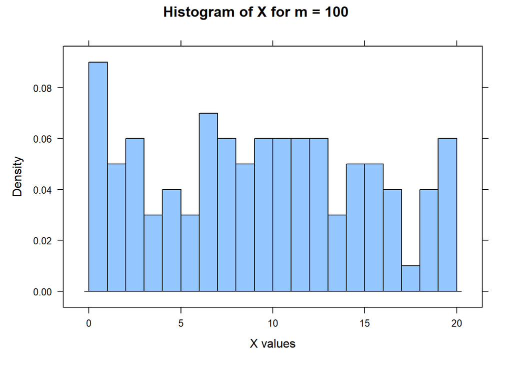

```r
# code to generate the X values
hist.X.vals <- function(vals){
  histogram(
    ~vals,
    type = "density",
    right = FALSE,
    breaks = seq(0, 20, by = 1),
    main = paste("Histogram of X for m =", length(vals)),
    xlab = "X values"
  )
}

#now make a histogram
X.vals.100 <- runif(n = 100, min = 0, max = 20)
hist.X.vals(X.vals.100)
```

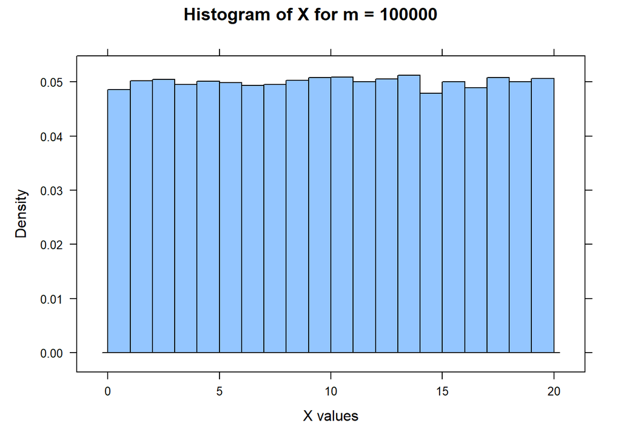

```r
X.vals.100000 <- runif(n = 10^5, min = 0, max = 20)
hist.X.vals(X.vals.100000)
```

Using the $m=100$ simulated values, the probability that $X<6$ is:

```r
p.hat.100 <- mean(X.vals.100 < 6)
p.hat.100
```

```
## [1] 0.3
```

Now do it again with $m=10^5$.

```r
p.hat.100000 <- mean(X.vals.100000 < 6)
p.hat.100000
```

```
## [1] 0.29885
```

#### Q1b

When m becomes larger, the distribution looks more uniform, more consistent with the name “uniform distribution”

#### Q1c

Assuming $X$ is uniformly distributed on the interval $[0, 20]$, the probability that $X < 6$ is:

$X \sim Unif[a,b]$

$P(X<6) = \frac{6-0}{20-0} = \frac{6}{20} = 0.3$

## Experiment 2: Still Waiting (Exponential)

```r
beta <- 20 #mean waiting time
lambda <- 1 / beta
```

#### Q2a

```r
pexp(6, lambda)
```

```
## [1] 0.2591818
```

#### Q2b

```r
# P(X < 10)
p.less.10 <- pexp(10, lambda)

# P(X > 15)
p.greater.15 <- 1 - pexp(15, lambda)

# P(5 < X < 10)
p.between.5.10 <- pexp(10, lambda) - pexp(5, lambda)

c("P(X<10)" = p.less.10,
  "P(X>15)" = p.greater.15,
  "P(5<X<10)" = p.between.5.10)
```

```
##   P(X<10)   P(X>15) P(5<X<10)
## 0.3934693 0.4723666 0.1722701
```

#### Q2c

```r
median_wait <- qexp(0.5, lambda)
median_wait
```

```
## [1] 13.86294
```

```r
pexp(15, 1/20)
```

```
## [1] 0.5276334
```

#### Q2d

```r
Q1 <- qexp(0.25, lambda)
Q3 <- qexp(0.75, lambda)
IQR <- Q3 - Q1

c(Q1 = Q1, Q3 = Q3, IQR = IQR)
```

```
##        Q1        Q3       IQR
##  5.753641 27.725887 21.972246
```

#### Q2e

The distribution of X is positively skewed.

```r
mu  <- beta
sdX <- beta
3 * (mu - median_wait) / sdX
```

```
## [1] 0.9205585
```

#### Q2f

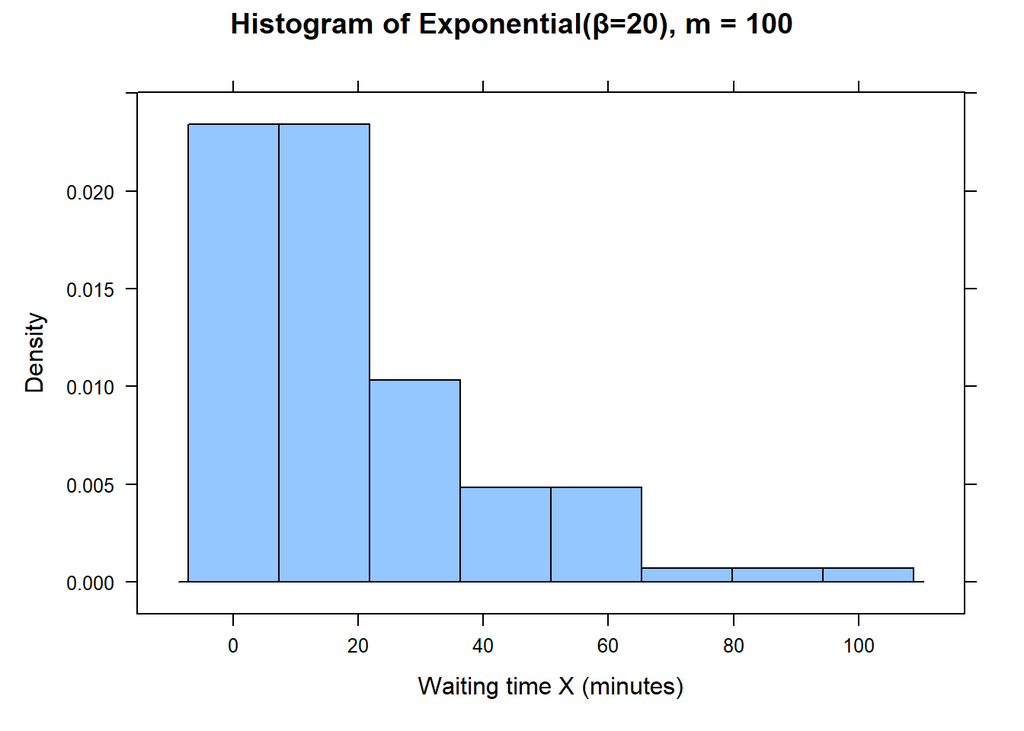

```r
hist.exp <- function(vals, m){
  histogram(
    ~ vals,
    type  = "density",
    right = FALSE,
    main  = paste("Histogram of Exponential(β=20), m =", m),
    xlab  = "Waiting time X (minutes)"
  )
}

X.exp.100 <- rexp(n = 100, lambda)
hist.exp(X.exp.100, 100)
```

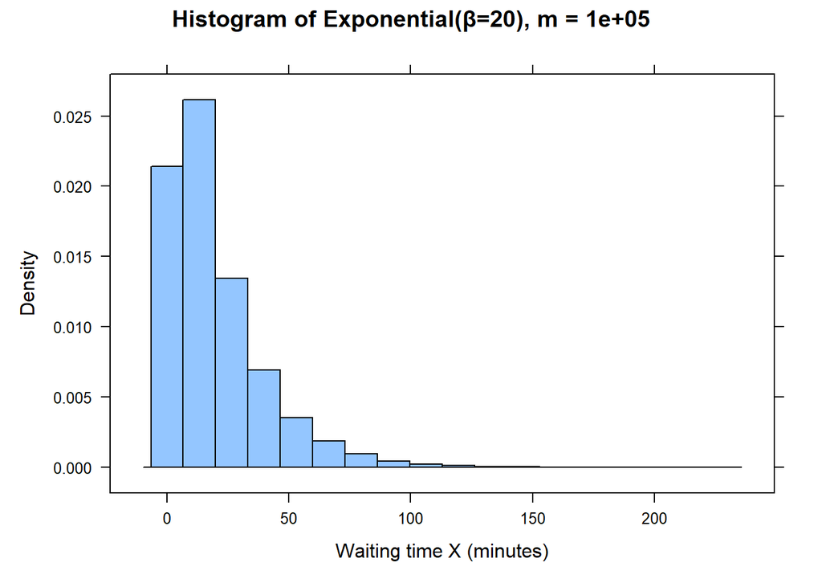

```r
X.exp.100000 <- rexp(n = 10^5, lambda)
hist.exp(X.exp.100000, 100000)
```

As m increases from 100 to 100000, the histogram becomes smoother and aligns more closely with the exponential shape.

#### Q2g

```r
mean(rexp(n = 10^5, lambda) < 6)
```

```
## [1] 0.25944
```

#### Q2h

$X \sim Exp(\lambda = \frac{1}{\beta})$

$P(X<6) = 1 - e^{- \frac{6}{20}} \approx 0.2592$

## Experiment 3: Quality Control (Normal Distribution)

```r
mu <- 9.01
sig <- 0.05
```

#### Q3a

```r
p.less.9.03 <- pnorm(9.03, mu, sig)
p.greater.9.02 <- 1 - pnorm(9.02, mu, sig)
p.between.8.9.9.1 <- pnorm(9.1,mu, sd = sig) - pnorm(8.9,  mu, sig)

c("P(X<9.03)"=p.less.9.03,
  "P(X>9.02)" = p.greater.9.02,
  "P(8.9<X<9.1)" = p.between.8.9.9.1)
```

```
##    P(X<9.03)    P(X>9.02) P(8.9<X<9.1)
##    0.6554217    0.4207403    0.9501662
```

#### Q3b

```r
q.95 <- qnorm(0.95, mu, sig)
q.5 <- qnorm(0.05, mu, sig)
q.25 <- qnorm(0.25, mu, sig)

c("Q95" = q.95, "Q5" = q.5, "Q25" = q.25)
```

```
##      Q95       Q5      Q25
## 9.092243 8.927757 8.976276
```

#### Q3c

```r
X.sim.100 <- rnorm(100, mu, sig)
mean(X.sim.100 > 8.9 & X.sim.100 < 9.1)
```

```
## [1] 0.96
```

```r
X.sim.100000 <- rnorm(10^5, mu, sig)
mean(X.sim.100000 > 8.9 & X.sim.100000 < 9.1)
```

```
## [1] 0.94934
```

#### Q3d

$P(8.9 < X < 9.1) = P(\frac{8.9 - \mu}{\sigma} < Z < \frac{9.1 - \mu}{\sigma}) = P(-2.2 < Z < 1.8) = \Phi(1.8) - \Phi(-2.2) = \Phi(1.8) - (1 - \Phi(2.2))$

$\Phi(1.8)\approx 0.9641, \Phi(2.2)\approx 0.9861 \rightarrow \Phi(-2.2)=1-0.9861=0.0139$

$\Rightarrow\ P(8.9<X<9.1)\approx 0.9641-0.0139=0.9502$